# Поиск и выбор набора данных для построения моделей машинного обучения

В качестве набора данных мы будем использовать набор данных, содержащий историю погоды в США с 1964 по 2013 год - https://data.world/carlvlewis/u-s-weather-outliers-1964

Датасет состоит ииз одного файла `weather-anomalies-1964-2013.csv`

Файл содержит следующие колонки:

- `date_str` – дата измерения погоды
- `degrees_from_mean`
- `id`
- `longitude`
- `latitude`
- `max_temp`
- `min_temp`
- `station_name`
- `type`
- `serialid`

В данной работе будем решать задачи регрессии.

# Импорт библиотек

Импортируем библиотеки с помощью команды import. Как правило, все команды import размещают в первых ячейках ноутбука.

```python
import numpy as np
import pandas as pd
import seaborn as sns
import matplotlib.pyplot as plt
import datetime
from sklearn.preprocessing import MinMaxScaler
from sklearn.linear_model import LinearRegression, LogisticRegression
from sklearn.preprocessing import LabelEncoder
from sklearn.model_selection import train_test_split
from sklearn.neighbors import KNeighborsRegressor, KNeighborsClassifier
from sklearn.metrics import accuracy_score, balanced_accuracy_score
from sklearn.metrics import precision_score, recall_score, f1_score, classification_report
from sklearn.metrics import confusion_matrix
from sklearn.metrics import plot_confusion_matrix
from sklearn.model_selection import GridSearchCV
from sklearn.metrics import mean_absolute_error, mean_squared_error, mean_squared_log_error, median_absolute_error, r2_score
from sklearn.metrics import roc_curve, roc_auc_score
from sklearn.svm import SVC, NuSVC, LinearSVC, OneClassSVM, SVR, NuSVR, LinearSVR
from sklearn.tree import DecisionTreeClassifier, DecisionTreeRegressor, export_graphviz
from sklearn.ensemble import RandomForestClassifier, RandomForestRegressor
from sklearn.ensemble import ExtraTreesClassifier, ExtraTreesRegressor
from sklearn.ensemble import GradientBoostingClassifier, GradientBoostingRegressor
%matplotlib inline
sns.set(style="ticks")
# import gmaps # не подходит, поскольку невозможно использовать этот API без платёжной системы Google
import pygeoplot as gp # Пакета нет в pip, установка мописана в gitHub
```

# Загрузка данных

Загрузим файлы датасета в помощью библиотеки Pandas.

Файл представляет собой данные в формате CSV (https://ru.wikipedia.org/wiki/CSV). Часто в файлах такого формата в качестве разделителей используются символы ",", ";" или табуляция. Поэтому вызывая метод `read_csv` всегда стоит явно указывать разделитель данных с помощью параметра `sep`. Чтобы узнать какой разделитель используется в файле его рекомендуется предварительно посмотреть в любом текстовом редакторе.

```python
original = pd.read_csv('weather-anomalies-1964-2013.csv', sep=",")
```

Пос кольку наборп данных очень большой, то будем использовать только первые 2000 строк

```python
original2000 = original.head(2000)
```

Удалим дкбликаты записей, если они присутствуют

```python
data = original2000.drop_duplicates()
```

# Проведение разведочного анализа данных. Построение графиков, необходимых для понимания структуры данных. Анализ и заполнение пропусков в данных.

## Основные характенристики набора данных

Первые и последние 5 строк выборки из датасета (далее - датасета)

```python
data
```

|  | date_str | degrees_from_mean | id | longitude | latitude | max_temp | min_temp | station_name | type | serialid |
| --- | --- | --- | --- | --- | --- | --- | --- | --- | --- | --- |
| 0 | 1977-02-19 | 8.61 | USC00103882 | -113.5472 | 43.7186 | 10.0 | -12.8 | GROUSE | Weak Hot | 1 |
| 1 | 1977-02-19 | 10.74 | USC00053951 | -107.1097 | 37.7717 | 11.1 | -8.9 | HERMIT 7 ESE | Weak Hot | 2 |
| 2 | 1977-02-19 | 20.46 | USC00040379 | -119.5128 | 37.0919 | 25.6 | 12.8 | AUBERRY 2 NW | Strong Hot | 3 |
| 3 | 1977-02-19 | 8.60 | USC00020808 | -109.7517 | 33.4783 | 20.0 | -3.9 | BLACK RIVER PUMPS | Weak Hot | 4 |
| 4 | 1977-02-19 | 10.30 | USC00042598 | -115.4508 | 33.8089 | 30.6 | 13.9 | EAGLE MTN | Weak Hot | 5 |
| ... | ... | ... | ... | ... | ... | ... | ... | ... | ... | ... |
| 1995 | 1977-08-28 | -12.11 | USC00355142 | -121.1461 | 44.6633 | 17.2 | 7.8 | MADRAS 2 N | Weak Cold | 1996 |
| 1996 | 1977-08-28 | -14.36 | USC00248809 | -113.9847 | 48.5003 | 11.7 | 5.6 | WEST GLACIER | Weak Cold | 1997 |
| 1997 | 1977-08-28 | 8.28 | USW00014739 | -71.0106 | 42.3606 | 35.0 | 20.6 | BOSTON LOGAN INTL AP | Weak Hot | 1998 |
| 1998 | 1977-08-28 | 9.83 | USW00023244 | -122.0481 | 37.4058 | 34.4 | 16.7 | MOFFETT FEDERAL AIRFIELD | Weak Hot | 1999 |
| 1999 | 1977-08-28 | 8.12 | USC00207280 | -84.5542 | 43.0114 | 33.3 | 22.8 | SAINT JOHNS | Weak Hot | 2000 |

2000 rows × 10 columns

Список колонок с типами данных

```python
data.dtypes
```

```
date_str              object
degrees_from_mean    float64
id                    object
longitude            float64
latitude             float64
max_temp             float64
min_temp             float64
station_name          object
type                  object
serialid               int64
dtype: object
```

Как выидим - тип даты определён неверно. Исправим это

```python
data['date_str'] = pd.to_datetime(data['date_str'], format="%Y-%m-%d")
```

Проверяем типы данных ещё раз

```python
data.dtypes
```

```
date_str             datetime64[ns]
degrees_from_mean           float64
id                           object
longitude                   float64
latitude                    float64
max_temp                    float64
min_temp                    float64
station_name                 object
type                         object
serialid                      int64
dtype: object
```

Как видим - типы данных стали верными. Выведем первые 5 строк датасета

```python
data.head()
```

|  | date_str | degrees_from_mean | id | longitude | latitude | max_temp | min_temp | station_name | type | serialid |
| --- | --- | --- | --- | --- | --- | --- | --- | --- | --- | --- |
| 0 | 1977-02-19 | 8.61 | USC00103882 | -113.5472 | 43.7186 | 10.0 | -12.8 | GROUSE | Weak Hot | 1 |
| 1 | 1977-02-19 | 10.74 | USC00053951 | -107.1097 | 37.7717 | 11.1 | -8.9 | HERMIT 7 ESE | Weak Hot | 2 |
| 2 | 1977-02-19 | 20.46 | USC00040379 | -119.5128 | 37.0919 | 25.6 | 12.8 | AUBERRY 2 NW | Strong Hot | 3 |
| 3 | 1977-02-19 | 8.60 | USC00020808 | -109.7517 | 33.4783 | 20.0 | -3.9 | BLACK RIVER PUMPS | Weak Hot | 4 |
| 4 | 1977-02-19 | 10.30 | USC00042598 | -115.4508 | 33.8089 | 30.6 | 13.9 | EAGLE MTN | Weak Hot | 5 |

Провекряем наличие пропущенных значений

```python
data.isnull().sum()
```

```
date_str             0
degrees_from_mean    0
id                   0
longitude            0
latitude             0
max_temp             0
min_temp             0
station_name         0
type                 0
serialid             0
dtype: int64
```

**Вывод:** Представленный набор данных не содержит пропусков.

## Построение графиков для понимания структуры данных

Парные диаграммы

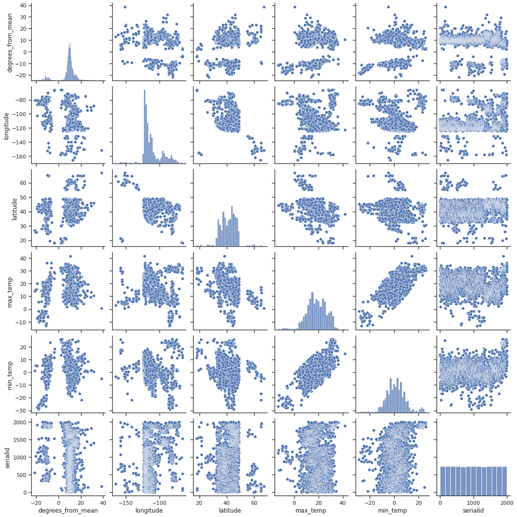

```python
sns.pairplot(data)
```

Выведем измерения погоды на карте с помощью библиотеки PyGeoPlot (https://github.com/romovpa/pygeoplot)

Поскольку оригинальный репозиторий содержит неактуальный код (см. раздел `issues`), то в данной научной исследовательской работе будем использовать форк - https://github.com/irina-goltsman/pygeoplot

Данный форк тоже содержит неактуальный код, поэтому приведу инструкцию по установке:

1. Выполнить следующие команды в теминале

```
$ git clone https://github.com/irina-goltsman/pygeoplot
$ cd pygeoplot
$ python setup.py install
```

1. Отредактировать `__init__.py` в установленном пакете (дописать символ `.` так, чтобы имена были относительными):

```
from .api import *
from .display import *
from .util import *
```

```python
m = gp.api.Map() # Создаём объект карты
```

Добавляем точки на карту

```python
for i in range(data.shape[0]):
    m.add_placemark((data.iloc[i]['latitude'], data.iloc[i]['longitude']), hint=data.iloc[i]['station_name'], content=data.iloc[i]['max_temp'])
```

```python
# Оцентруем карту относительно одной из точек набора данных
m.set_state((data.iloc[2]['latitude'], data.iloc[2]['longitude']), zoom=2)
m.display() # Выводим карту
```

[output not shown]

# Обработка данных

## Кодирование категориальных признпков

Поскольку алгоритмы машинного обучения вог многих библиотеках не работают с категориальными признаками, то закодируекм их с помощью `LabelEncoder`

```python
le = LabelEncoder()
    # "date_str"
le.fit(data.date_str.drop_duplicates())
data.date_str = le.transform(data.date_str)
    # "id"
le.fit(data.id.drop_duplicates())
data.id = le.transform(data.id)
    # "station_name"
le.fit(data.station_name.drop_duplicates())
data.station_name = le.transform(data.station_name)
    # "type"
le.fit(data.type.drop_duplicates())
data.type = le.transform(data.type)
```

```python
data_clone = data.copy()
```

## Масштабирование данных

Для улучшения качества алгоритмов машинного обучения отмасштабируем данные.

```python
# Числовые колонки для масштабирования
scale_cols = ['degrees_from_mean', 'longitude', 'latitude', 'max_temp', 'min_temp']
```

```python
sc1 = MinMaxScaler()
sc1_data = sc1.fit_transform(data_clone[scale_cols])
```

Добавим масштабированные данные в набор данных

```python
for i in range(len(scale_cols)):
    col = scale_cols[i]
    new_col_name = col + '_scaled'
    data_clone[new_col_name] = sc1_data[:,i]
```

```python
data_clone
```

|  | date_str | degrees_from_mean | id | longitude | latitude | max_temp | min_temp | station_name | type | serialid | degrees_from_mean_scaled | longitude_scaled | latitude_scaled | max_temp_scaled | min_temp_scaled |
| --- | --- | --- | --- | --- | --- | --- | --- | --- | --- | --- | --- | --- | --- | --- | --- |
| 0 | 11 | 8.61 | 207 | -113.5472 | 43.7186 | 10.0 | -12.8 | 312 | 3 | 1 | 0.500995 | 0.519972 | 0.524524 | 0.423636 | 0.292727 |
| 1 | 11 | 10.74 | 160 | -107.1097 | 37.7717 | 11.1 | -8.9 | 345 | 3 | 2 | 0.536306 | 0.584477 | 0.402632 | 0.443636 | 0.363636 |
| 2 | 11 | 20.46 | 42 | -119.5128 | 37.0919 | 25.6 | 12.8 | 30 | 1 | 3 | 0.697447 | 0.460196 | 0.388698 | 0.707273 | 0.758182 |
| 3 | 11 | 8.60 | 10 | -109.7517 | 33.4783 | 20.0 | -3.9 | 70 | 3 | 4 | 0.500829 | 0.558003 | 0.314631 | 0.605455 | 0.454545 |
| 4 | 11 | 10.30 | 65 | -115.4508 | 33.8089 | 30.6 | 13.9 | 225 | 3 | 5 | 0.529012 | 0.500898 | 0.321407 | 0.798182 | 0.778182 |
| ... | ... | ... | ... | ... | ... | ... | ... | ... | ... | ... | ... | ... | ... | ... | ... |
| 1995 | 12 | -12.11 | 502 | -121.1461 | 44.6633 | 17.2 | 7.8 | 454 | 2 | 1996 | 0.157493 | 0.443830 | 0.543888 | 0.554545 | 0.667273 |
| 1996 | 12 | -14.36 | 373 | -113.9847 | 48.5003 | 11.7 | 5.6 | 865 | 2 | 1997 | 0.120192 | 0.515588 | 0.622534 | 0.454545 | 0.627273 |
| 1997 | 12 | 8.28 | 751 | -71.0106 | 42.3606 | 35.0 | 20.6 | 81 | 3 | 1998 | 0.495524 | 0.946194 | 0.496690 | 0.878182 | 0.900000 |
| 1998 | 12 | 9.83 | 811 | -122.0481 | 37.4058 | 34.4 | 16.7 | 514 | 3 | 1999 | 0.521220 | 0.434792 | 0.395132 | 0.867273 | 0.829091 |
| 1999 | 12 | 8.12 | 296 | -84.5542 | 43.0114 | 33.3 | 22.8 | 712 | 3 | 2000 | 0.492871 | 0.810485 | 0.510029 | 0.847273 | 0.940000 |

2000 rows × 15 columns

Проверяем, что масштабирование не повлияло на распределение данных

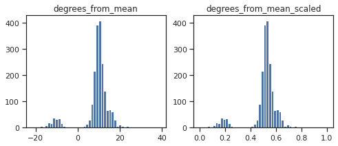

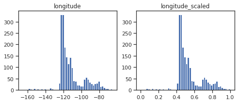

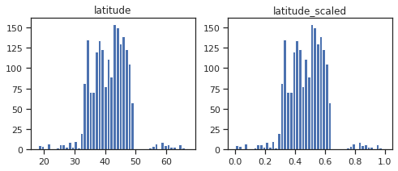

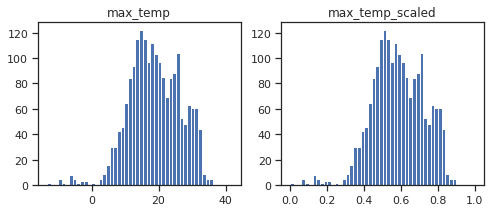

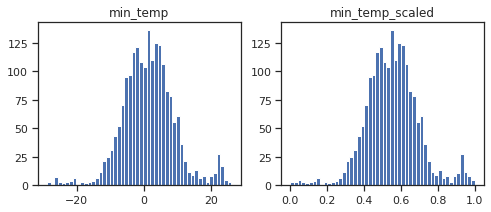

```python
for col in scale_cols:
    col_scaled = col + '_scaled'

    fig, ax = plt.subplots(1, 2, figsize=(8,3))
    ax[0].hist(data_clone[col], 50)
    ax[1].hist(data_clone[col_scaled], 50)
    ax[0].title.set_text(col)
    ax[1].title.set_text(col_scaled)
    plt.show()
```

# Проведение корреляционного анализа данных. Формирование промежуточных выводов о возможности построения моделей машинного обучения.

```python
corr_cols_1 = data_clone.columns[:-5]
corr_cols_1
```

```
Index(['date_str', 'degrees_from_mean', 'id', 'longitude', 'latitude',
       'max_temp', 'min_temp', 'station_name', 'type', 'serialid'],
      dtype='object')
```

```python
scale_cols_postfix = [x+'_scaled' for x in scale_cols]
corr_cols_2 = scale_cols_postfix
corr_cols_2
```

```
['degrees_from_mean_scaled',
 'longitude_scaled',
 'latitude_scaled',
 'max_temp_scaled',
 'min_temp_scaled']
```

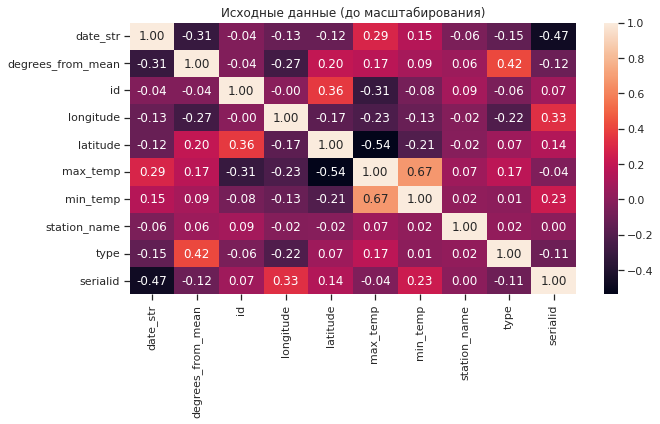

```python
fig, ax = plt.subplots(figsize=(10,5))
sns.heatmap(data_clone[corr_cols_1].corr(), annot=True, fmt='.2f')
ax.set_title('Исходные данные (до масштабирования)')
plt.show()
```

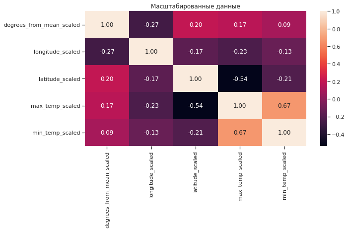

```python
fig, ax = plt.subplots(figsize=(10,5))
sns.heatmap(data_clone[corr_cols_2].corr(), annot=True, fmt='.2f')
ax.set_title('Масштабированные данные')
plt.show()
```

# Выбор метрик для последующей оценки качества моделей.

## Сохранение и визуализация метрик

Разработаем класс, который позволит сохранять метрики качества построенных моделей и реализует визуализацию метрик качества.

```python
class MetricLogger:

    def __init__(self):
        self.df = pd.DataFrame(
            {'metric': pd.Series([], dtype='str'),
            'alg': pd.Series([], dtype='str'),
            'value': pd.Series([], dtype='float')})

    def add(self, metric, alg, value):
        """
        Добавление значения
        """
        # Удаление значения если оно уже было ранее добавлено
        self.df.drop(self.df[(self.df['metric']==metric)&(self.df['alg']==alg)].index, inplace = True)
        # Добавление нового значения
        temp = [{'metric':metric, 'alg':alg, 'value':value}]
        self.df = pd.concat([self.df, pd.DataFrame(temp)], ignore_index=True)

    def get_data_for_metric(self, metric, ascending=True):
        """
        Формирование данных с фильтром по метрике
        """
        temp_data = self.df[self.df['metric']==metric]
        temp_data_2 = temp_data.sort_values(by='value', ascending=ascending)
        return temp_data_2['alg'].values, temp_data_2['value'].values

    def plot(self, str_header, metric, ascending=True, figsize=(5, 5)):
        """
        Вывод графика
        """
        array_labels, array_metric = self.get_data_for_metric(metric, ascending)
        fig, ax1 = plt.subplots(figsize=figsize)
        pos = np.arange(len(array_metric))
        rects = ax1.barh(pos, array_metric,
                         align='center',
                         height=0.5,
                         tick_label=array_labels)
        ax1.set_title(str_header)
        for a,b in zip(pos, array_metric):
            plt.text(0.5, a-0.05, str(round(b,3)), color='white')
        plt.show()
```

# Выбор наиболее подходящих моделей для решения задачи классификации или регрессии.

Для задачи регрессии будем использовать следующие модели:

- Линейная регрессия
- Метод ближайших соседей
- Машина опорных векторов
- Решающее дерево
- Случайный лес
- Градиентный бустинг

# Формирование обучающей и тестовой выборок на основе исходного набора данных.

На основе масштабированных данных выделим обучающую и тестовую выборки с помощью фильтра

```python
X = data_clone[["date_str", "degrees_from_mean_scaled", "id", "longitude_scaled", "latitude_scaled", "min_temp_scaled", "station_name", "type", "serialid"]]
Y = data_clone["max_temp_scaled"]
print('Входные данные:\n\n', X.head(), '\n\nВыходные данные:\n\n', Y.head())
```

```
Входные данные:

    date_str  degrees_from_mean_scaled   id  longitude_scaled  latitude_scaled  \
0        11                  0.500995  207          0.519972         0.524524
1        11                  0.536306  160          0.584477         0.402632
2        11                  0.697447   42          0.460196         0.388698
3        11                  0.500829   10          0.558003         0.314631
4        11                  0.529012   65          0.500898         0.321407

   min_temp_scaled  station_name  type  serialid
0         0.292727           312     3         1
1         0.363636           345     3         2
2         0.758182            30     1         3
3         0.454545            70     3         4
4         0.778182           225     3         5

Выходные данные:

 0    0.423636
1    0.443636
2    0.707273
3    0.605455
4    0.798182
Name: max_temp_scaled, dtype: float64
```

```python
X_train,  X_test,  Y_train,  Y_test = train_test_split(X,  Y, random_state = 2022, test_size = 0.1)
```

# Построение базового решения (baseline) для выбранных моделей без подбора гиперпараметров. Производится обучение моделей на основе обучающей выборки и оценка качества моделей на основе тестовой выборки.

Решение задачи регрессии

```python
# Модели
regr_models = {'LR': LinearRegression(),
               'KNN_5':KNeighborsRegressor(n_neighbors=5),
               'SVR':SVR(),
               'Tree':DecisionTreeRegressor(),
               'RF':RandomForestRegressor(),
               'GB':GradientBoostingRegressor()}
```

```python
# Сохранение метрик
regrMetricLogger = MetricLogger()
```

```python
def regr_train_model(model_name, model, regrMetricLogger):
    model.fit(X_train, Y_train)
    Y_pred = model.predict(X_test)

    mae = mean_absolute_error(Y_test, Y_pred)
    mse = mean_squared_error(Y_test, Y_pred)
    r2 = r2_score(Y_test, Y_pred)

    regrMetricLogger.add('MAE', model_name, mae)
    regrMetricLogger.add('MSE', model_name, mse)
    regrMetricLogger.add('R2', model_name, r2)

    print('{} \t MAE={}, MSE={}, R2={}'.format(
        model_name, round(mae, 3), round(mse, 3), round(r2, 3)))
```

```python
for model_name, model in regr_models.items():
    regr_train_model(model_name, model, regrMetricLogger)
```

```
LR 	 MAE=0.05, MSE=0.005, R2=0.764
KNN_5 	 MAE=0.075, MSE=0.01, R2=0.466
SVR 	 MAE=0.081, MSE=0.012, R2=0.385
Tree 	 MAE=0.031, MSE=0.003, R2=0.86
RF 	 MAE=0.022, MSE=0.001, R2=0.946
GB 	 MAE=0.031, MSE=0.002, R2=0.904
```

# Подбор гиперпараметров для выбранных моделей с использованием методов кросс-валидации.

```python
n_range = np.array(range(1,1000,5))
tuned_parameters = [{'n_neighbors': n_range}]
tuned_parameters
```

```
[{'n_neighbors': array([  1,   6,  11,  16,  21,  26,  31,  36,  41,  46,  51,  56,  61,
          66,  71,  76,  81,  86,  91,  96, 101, 106, 111, 116, 121, 126,
         131, 136, 141, 146, 151, 156, 161, 166, 171, 176, 181, 186, 191,
         196, 201, 206, 211, 216, 221, 226, 231, 236, 241, 246, 251, 256,
         261, 266, 271, 276, 281, 286, 291, 296, 301, 306, 311, 316, 321,
         326, 331, 336, 341, 346, 351, 356, 361, 366, 371, 376, 381, 386,
         391, 396, 401, 406, 411, 416, 421, 426, 431, 436, 441, 446, 451,
         456, 461, 466, 471, 476, 481, 486, 491, 496, 501, 506, 511, 516,
         521, 526, 531, 536, 541, 546, 551, 556, 561, 566, 571, 576, 581,
         586, 591, 596, 601, 606, 611, 616, 621, 626, 631, 636, 641, 646,
         651, 656, 661, 666, 671, 676, 681, 686, 691, 696, 701, 706, 711,
         716, 721, 726, 731, 736, 741, 746, 751, 756, 761, 766, 771, 776,
         781, 786, 791, 796, 801, 806, 811, 816, 821, 826, 831, 836, 841,
         846, 851, 856, 861, 866, 871, 876, 881, 886, 891, 896, 901, 906,
         911, 916, 921, 926, 931, 936, 941, 946, 951, 956, 961, 966, 971,
         976, 981, 986, 991, 996])}]
```

```python
%%time
regr_gs = GridSearchCV(KNeighborsRegressor(), tuned_parameters, cv=5, scoring='neg_mean_squared_error')
regr_gs.fit(X_train, Y_train)
```

```
CPU times: user 2min 11s, sys: 1min 55s, total: 4min 6s
Wall time: 30.2 s
```

```
GridSearchCV(cv=5, estimator=KNeighborsRegressor(),
             param_grid=[{'n_neighbors': array([  1,   6,  11,  16,  21,  26,  31,  36,  41,  46,  51,  56,  61,
        66,  71,  76,  81,  86,  91,  96, 101, 106, 111, 116, 121, 126,
       131, 136, 141, 146, 151, 156, 161, 166, 171, 176, 181, 186, 191,
       196, 201, 206, 211, 216, 221, 226, 231, 236, 241, 246, 251, 256,
       261, 266, 271, 276, 281, 286, 291, 296, 301, 306, 311, 316, 321,
       326, 331, 336, 341, 346, 351, 356,...
       586, 591, 596, 601, 606, 611, 616, 621, 626, 631, 636, 641, 646,
       651, 656, 661, 666, 671, 676, 681, 686, 691, 696, 701, 706, 711,
       716, 721, 726, 731, 736, 741, 746, 751, 756, 761, 766, 771, 776,
       781, 786, 791, 796, 801, 806, 811, 816, 821, 826, 831, 836, 841,
       846, 851, 856, 861, 866, 871, 876, 881, 886, 891, 896, 901, 906,
       911, 916, 921, 926, 931, 936, 941, 946, 951, 956, 961, 966, 971,
       976, 981, 986, 991, 996])}],
             scoring='neg_mean_squared_error')
```

```python
# Лучшая модель
regr_gs.best_estimator_
```

```
KNeighborsRegressor(n_neighbors=16)
```

```python
# Лучшее значение параметров
regr_gs.best_params_
```

```
{'n_neighbors': 16}
```

```python
regr_gs_best_params_txt = str(regr_gs.best_params_['n_neighbors'])
regr_gs_best_params_txt
```

```
'16'
```

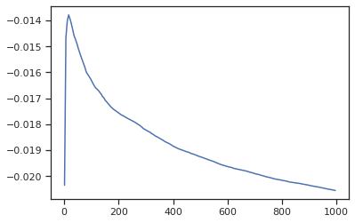

```python
# Изменение качества на тестовой выборке в зависимости от К-соседей
plt.plot(n_range, regr_gs.cv_results_['mean_test_score'])
```

# Повторение пункта 8 для найденных оптимальных значений гиперпараметров. Сравнение качества полученных моделей с качеством baseline-моделей.

```python
regr_models_grid = {'KNN_5':KNeighborsRegressor(n_neighbors=5), str('KNN_'+regr_gs_best_params_txt):regr_gs.best_estimator_}
```

```python
for model_name, model in regr_models_grid.items():
    regr_train_model(model_name, model, regrMetricLogger)
```

```
KNN_5 	 MAE=0.075, MSE=0.01, R2=0.466
KNN_16 	 MAE=0.074, MSE=0.01, R2=0.464
```

# Формирование выводов о качестве построенных моделей на основе выбранных метрик.

Метрики качества модели

```python
regr_metrics = regrMetricLogger.df['metric'].unique()
regr_metrics
```

```
array(['MAE', 'MSE', 'R2'], dtype=object)
```

[figure not shown]

```python
regrMetricLogger.plot('Метрика: ' + 'MAE', 'MAE', ascending=False, figsize=(7, 6))
```

```python
regrMetricLogger.plot('Метрика: ' + 'MSE', 'MSE', ascending=False, figsize=(7, 6))
```

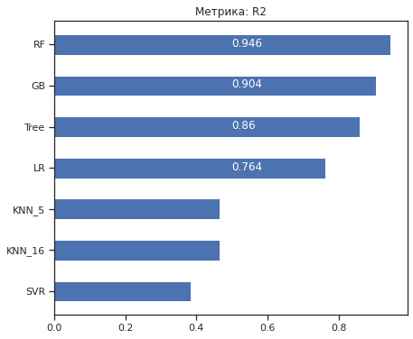

```python
regrMetricLogger.plot('Метрика: ' + 'R2', 'R2', ascending=True, figsize=(7, 6))
```

# Вывод